# Exploratory Data Analysis in Action - EDA: Targets

By **Gruppe Blau**:

- Daria
- Cedric
- Leonid
- Aleks

In this section we explore the [*Arial Bombing Data Set*](https://www.kaggle.com/usaf/world-war-ii) and apply techniques referred to as **Exploratory Data Analysis**.

**Import statements**

```python
import numpy as np
import pandas as pd
import matplotlib.pyplot as plt
import geopandas as gpd
from shapely.geometry import Point
from shapely.geometry import Polygon
import os
import sys
import warnings
```

**Global settings**

```python
pd.options.display.max_rows = 999
pd.options.display.max_columns = 100
plt.rcParams["figure.figsize"] = [20,10] # increase default figure size
warnings.filterwarnings("ignore") # supress all warnings
```

**Load data set**

```python
import pickle
gdf_europe = pickle.load( open( "../data/gdf_europe.p", "rb" ) )
europe = pickle.load( open( "../data/europe.p", "rb" ) )
```

## Research questions

**Targets**

- Q1: Which cities were the 15 most frequent targets?
- Q2: How much high explosives (in tons) went down on the 25 most frequent targets?
- Q3: How did the aerial attacks change over time for the 15 most frequent targeted cities?

## Data preparation

- Only copy useful columns
- Determine invalid entries (City names as Coordinates, e.g. 10 00 N 110 30 E)
  - That crazy looking String in str.contains() represents any String which begins with two numbers (see Regular Expression/Regex)

```python
df_tar = gdf_europe[['Mission Date', 'Target City', 'High Explosives Weight (Tons)', 'geometry']].copy()
print(df_tar.shape)
df_tar_anfang = gdf_europe[['Mission Date', 'Target City', 'High Explosives Weight (Tons)', 'geometry']].copy()
df_tar.loc[df_tar['Target City'].str.contains(r'([0-9]{2})\w', na=False)]
```

```
(120068, 4)
```

|  | Mission Date | Target City | High Explosives Weight (Tons) | geometry |
| --- | --- | --- | --- | --- |
| 71 | 1943-08-15 | 37 20 N 014 00 E | 1.0 | POINT (14.00000 37.33000) |
| 72 | 1943-08-15 | 37 20 N 014 00 E | 1.0 | POINT (14.00000 37.33000) |
| 73 | 1943-08-15 | 37 20 N 014 00 E | 1.0 | POINT (14.00000 37.33000) |
| 250 | 1945-02-16 | 47 00 N 017 00 E | 2.0 | POINT (17.00000 47.00000) |
| 261 | 1945-02-16 | 50 40 N 008 00 E | 61.0 | POINT (8.00000 50.67000) |
| ... | ... | ... | ... | ... |
| 178144 | 1944-07-28 | 41 00 N 016 40 E | 12.0 | POINT (16.67000 41.00000) |
| 178145 | 1944-07-28 | 41 00 N 016 40 E | 12.0 | POINT (16.67000 41.00000) |
| 178146 | 1944-07-28 | 41 00 N 016 40 E | 12.0 | POINT (16.67000 41.00000) |
| 178147 | 1944-07-28 | 41 00 N 016 40 E | 12.0 | POINT (16.67000 41.00000) |
| 178148 | 1944-07-28 | 41 00 N 016 40 E | 12.0 | POINT (16.67000 41.00000) |

7360 rows × 4 columns

**Remove invalid entries by negating the loc**

Because df_tar.loc returns a set of rows with fixed index, we need to reset it (and drop the old index)

```python
df_tar = df_tar.loc[~df_tar['Target City'].str.contains(r'([0-9]{2})\w', na=False)].reset_index(drop=True)
print(df_tar.shape)
df_tar
```

```
(112708, 4)
```

|  | Mission Date | Target City | High Explosives Weight (Tons) | geometry |
| --- | --- | --- | --- | --- |
| 0 | 1943-08-15 | SPADAFORA | 10.0 | POINT (15.37000 38.22000) |
| 1 | 1943-08-15 | COSENZA | 9.0 | POINT (16.25000 39.27000) |
| 2 | 1943-08-15 | GIOJA TAURO | 7.5 | POINT (15.90000 38.43000) |
| 3 | 1943-08-15 | SCILLA | 0.0 | POINT (15.72000 38.23000) |
| 4 | 1943-08-15 | GIOJA TAURO | 0.0 | POINT (15.90000 38.43000) |
| ... | ... | ... | ... | ... |
| 112703 | 1945-02-15 | SPILIMBERGO | 36.0 | POINT (12.90000 46.10000) |
| 112704 | 1945-02-15 | SPILIMBERGO | 36.0 | POINT (12.90000 46.10000) |
| 112705 | 1945-02-15 | ARAD | 2.0 | POINT (21.32000 46.18000) |
| 112706 | 1945-02-15 | ABBAZIA | NaN | POINT (14.28000 45.32000) |
| 112707 | 1945-02-15 | FIUME OIL REFINERY | NaN | POINT (14.43000 45.33000) |

112708 rows × 4 columns

**Adding the ../src directory to our system path to import helper_funcs**

```python
src_dir = os.path.abspath(os.path.join(os.getcwd(), os.pardir, 'src'))
sys.path.append(src_dir)

import helper_funcs as hf
```

**Generate geopandas object**

```python
gdf = gpd.GeoDataFrame(df_tar, geometry=df_tar['geometry'])
poly_europe = gpd.GeoSeries([Polygon([(-27,33), (45,33), (45,73.5), (-27,73.5)])])
bb_europe = gpd.GeoDataFrame({'geometry': poly_europe})
```

**Assign crs and generate the europe plot map**

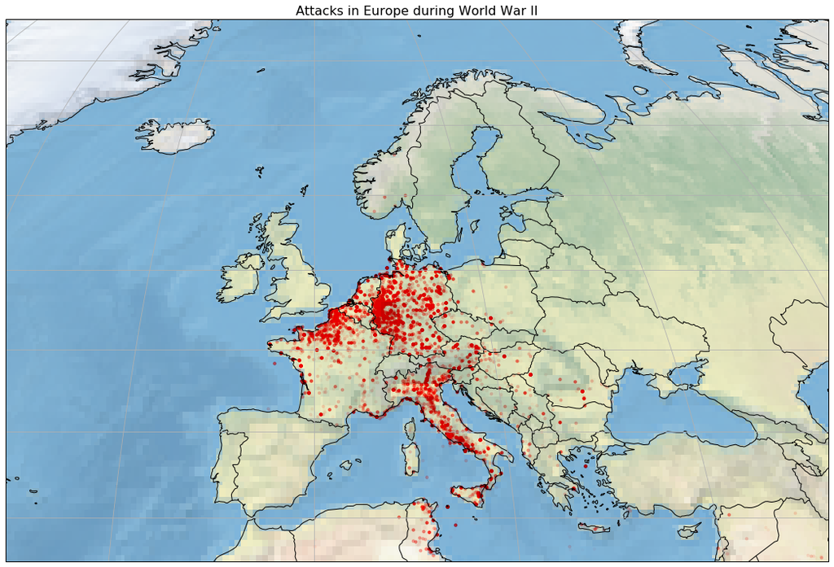

```python
gdf_europe = gpd.sjoin(gdf, bb_europe, how="inner", op='intersects').drop("index_right", axis=1)

hf.cuteplot(gpd_df=gdf_europe, crs="Mollweide", title="Attacks in Europe during World War II",markersize=10) # changed hf.cuteplot to accept markersize variable
```

# Q1: Which cities were the 15 most frequent targets?

**Generating a table of our data of the first 15 values**

```python
top_15 = df_tar['Target City'].value_counts().head(15)
top_15
```

```
BERLIN               2546
HAMBURG              1951
COLOGNE              1907
BREMEN               1880
KIEL                 1281
KASSEL               1231
MUNICH               1005
MERSEBURG            1003
FRANKFURT AM MAIN     970
BREST                 968
HANNOVER              910
VIENNA                883
MANNHEIM              855
LUDWIGSHAFEN          826
ESSEN                 810
Name: Target City, dtype: int64
```

**Generating bar graph**

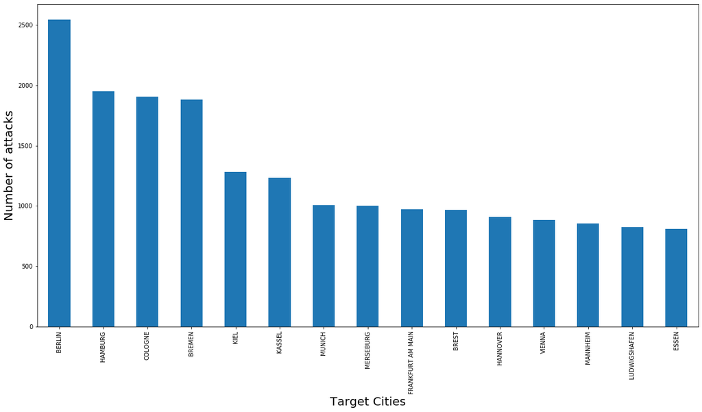

```python
fig,ax = plt.subplots()
ax.set_ylabel('Number of attacks',size=20)
ax.set_xlabel('Target Cities',size=20)

top_15.plot.bar(x='Target City', y='Number of Attacks',ax=ax);
```

# Q2: How much high explosives (in tons) went down on the 25 most frequent targets?

**Counting how many entries each city has and saving the count it to a dictionary**

```python
attack_counts = df_tar['Target City'].value_counts().to_dict()
```

That's how the dictionary looks like:

```python
count = 0
for k,v in attack_counts.items():
    print(f'key: {k}, value: {v}')
    if (count == 5):
        break
    count += 1
```

```
key: BERLIN, value: 2546
key: HAMBURG, value: 1951
key: COLOGNE, value: 1907
key: BREMEN, value: 1880
key: KIEL, value: 1281
key: KASSEL, value: 1231
```

**Generating column by adding 'Attack Count' to 'Target City'**

```python
df_tar['Attack Count'] = df_tar['Target City'].map(attack_counts)
df_tar.sort_values(['Attack Count', 'Mission Date'], ascending=[False,True], inplace=True) # Sort entries by Attack Count (high first) and Mission Date (low first)
df_tar['Target City'].unique()[0:25]
```

```
array(['BERLIN', 'HAMBURG', 'COLOGNE', 'BREMEN', 'KIEL', 'KASSEL',
       'MUNICH', 'MERSEBURG', 'FRANKFURT AM MAIN', 'BREST', 'HANNOVER',
       'VIENNA', 'MANNHEIM', 'LUDWIGSHAFEN', 'ESSEN', 'WILHELMSHAVEN',
       'DUSSELDORF', 'BRUNSWICK', 'GELSENKIRCHEN', 'EMDEN', 'DUISBURG',
       'MAGDEBURG', 'MUNSTER', 'DORTMUND', 'OSNABRUCK'], dtype=object)
```

**Generating our 25 cities and creating a pretty plot**

```python
cities = df_tar['Target City'].unique()[0:25]
```

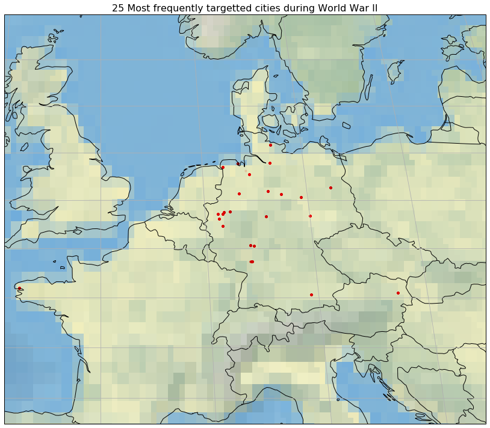

```python
gdf = gpd.GeoDataFrame(df_tar.loc[df_tar['Target City'].isin(cities)], geometry=df_tar['geometry'])

gdf_europe = gpd.sjoin(gdf, bb_europe, how="inner", op='intersects').drop("index_right", axis=1)

hf.cuteplot(gpd_df=gdf_europe, crs="Mollweide", title="25 Most frequently targetted cities during World War II",map_extend=(-5,20,43,60),markersize=10)
```

**Create Numpy Array of Citites and Total Weight of Explosives (Tons)**

```python
city_bombs = []
for city in cities:
    print(city + " " + str(df_tar.loc[df_tar['Target City'] == city]['High Explosives Weight (Tons)'].sum()))
    city_bombs.append([city, df_tar.loc[df_tar['Target City'] == city]['High Explosives Weight (Tons)'].sum()])
city_bombs = np.array(city_bombs)
```

```
BERLIN 65504.0
HAMBURG 51343.0
COLOGNE 44159.0
BREMEN 35293.0
KIEL 32116.0
KASSEL 27200.0
MUNICH 28321.0
MERSEBURG 31156.0
FRANKFURT AM MAIN 27664.0
BREST 23870.0
HANNOVER 23785.0
VIENNA 35075.0
MANNHEIM 20461.0
LUDWIGSHAFEN 19398.0
ESSEN 29671.0
WILHELMSHAVEN 14952.0
DUSSELDORF 15801.0
BRUNSWICK 22182.0
GELSENKIRCHEN 32279.0
EMDEN 8033.0
DUISBURG 22979.0
MAGDEBURG 18067.0
MUNSTER 14687.0
DORTMUND 29983.0
OSNABRUCK 10883.0
```

**Convert the Numpy Array to a Pandas DataFrame**

```python
df_city_bombs = pd.DataFrame(data=city_bombs[:,1].astype(float), # all rows, second column (Amount of Explosives) as float data
                             index=city_bombs[:,0], # set City Name as Index
                             columns=['High Explosives Weight (Tons)'])
df_city_bombs
```

|  | High Explosives Weight (Tons) |
| --- | --- |
| BERLIN | 65504.0 |
| HAMBURG | 51343.0 |
| COLOGNE | 44159.0 |
| BREMEN | 35293.0 |
| KIEL | 32116.0 |
| KASSEL | 27200.0 |
| MUNICH | 28321.0 |
| MERSEBURG | 31156.0 |
| FRANKFURT AM MAIN | 27664.0 |
| BREST | 23870.0 |
| HANNOVER | 23785.0 |
| VIENNA | 35075.0 |
| MANNHEIM | 20461.0 |
| LUDWIGSHAFEN | 19398.0 |
| ESSEN | 29671.0 |
| WILHELMSHAVEN | 14952.0 |
| DUSSELDORF | 15801.0 |
| BRUNSWICK | 22182.0 |
| GELSENKIRCHEN | 32279.0 |
| EMDEN | 8033.0 |
| DUISBURG | 22979.0 |
| MAGDEBURG | 18067.0 |
| MUNSTER | 14687.0 |
| DORTMUND | 29983.0 |
| OSNABRUCK | 10883.0 |

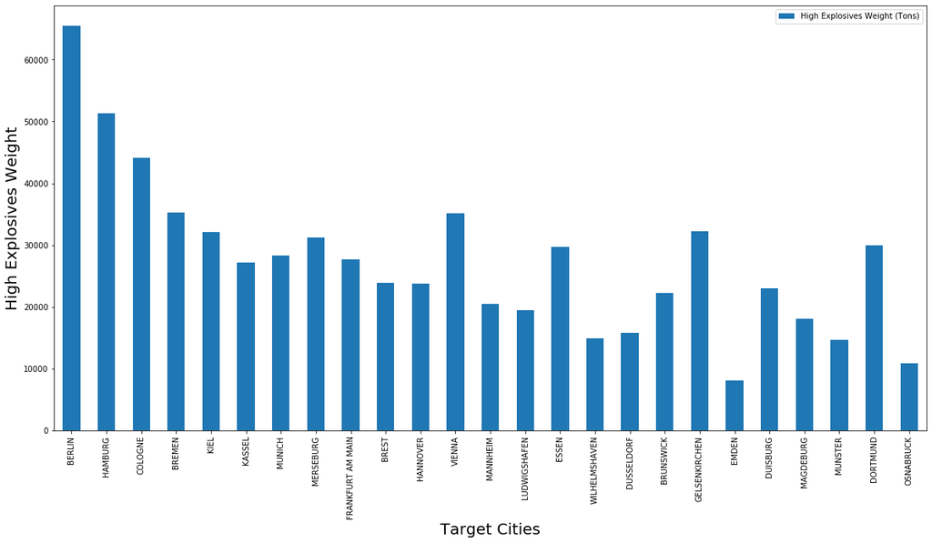

```python
fig,ax=plt.subplots()
ax.set_ylabel('High Explosives Weight',size=20)
ax.set_xlabel('Target Cities',size=20)

df_city_bombs.plot.bar(ax=ax);
```

# Q3: How did the aerial attacks change over time for the 15 most frequent targeted cities?

**Count the amount of explosives for individual cities for each year and save it to an Numpy Array**

```python
unique_years = np.array([i for i in range(df_tar['Mission Date'].dt.year.min(), df_tar['Mission Date'].dt.year.max() + 1)])

city_year = []
# Fuer alle Staedte
for city in cities[0:15]:
    # erstelle temporaere Liste, wobei erster Eintrag Stadtname ist
    year_arr = [city]
    # Fuer Jahre in (1939,...,1945)
    for year in unique_years:
        # Fuege Summe an 'Explosionsstoff' zur temporaeren Liste hinzu
        # year_arr = [Stadtname, Expl. in 1939, 1940, ..., 1945]
        year_arr.append((df_tar.loc[
                            (df_tar['Mission Date'].dt.year == year) &
                            (df_tar['Target City'] == city)
                        ]['High Explosives Weight (Tons)'].sum()))
    # Fuege temporaere Liste zur Gesamtliste hinzu
    city_year.append(year_arr)
city_year = np.array(city_year)
```

**Save 'city_year' as Pandas DataFrame**

```python
df_city_year = pd.DataFrame(data=city_year[:,1:].astype(float),
                  columns=unique_years.astype(int),
                  index=cities[0:15])
df_city_year
```

|  | 1939 | 1940 | 1941 | 1942 | 1943 | 1944 | 1945 |
| --- | --- | --- | --- | --- | --- | --- | --- |
| BERLIN | 0.0 | 583.0 | 886.0 | 2.0 | 12498.0 | 36083.0 | 15452.0 |
| HAMBURG | 0.0 | 550.0 | 2159.0 | 1145.0 | 7026.0 | 23630.0 | 16833.0 |
| COLOGNE | 0.0 | 228.0 | 2994.0 | 1480.0 | 4651.0 | 27003.0 | 7803.0 |
| BREMEN | 0.0 | 177.0 | 1913.0 | 2089.0 | 12785.0 | 9241.0 | 9088.0 |
| KIEL | 0.0 | 220.0 | 2101.0 | 645.0 | 4087.0 | 11200.0 | 13863.0 |
| KASSEL | 0.0 | 21.0 | 82.0 | 324.0 | 2771.0 | 19738.0 | 4264.0 |
| MUNICH | 0.0 | 30.0 | 5.0 | 280.0 | 1695.0 | 20575.0 | 5736.0 |
| MERSEBURG | 0.0 | 116.0 | 28.0 | 0.0 | 0.0 | 27464.0 | 3548.0 |
| FRANKFURT AM MAIN | 0.0 | 68.0 | 853.0 | 564.0 | 3134.0 | 19492.0 | 3553.0 |
| BREST | 0.0 | 20.0 | 3760.0 | 1258.0 | 617.0 | 18215.0 | 0.0 |
| HANNOVER | 0.0 | 74.0 | 1032.0 | 52.0 | 4912.0 | 9447.0 | 8268.0 |
| VIENNA | 0.0 | 0.0 | 0.0 | 0.0 | 27.0 | 19062.0 | 15986.0 |
| MANNHEIM | 0.0 | 235.0 | 1068.0 | 546.0 | 4136.0 | 8585.0 | 5891.0 |
| LUDWIGSHAFEN | 0.0 | 77.0 | 188.0 | 7.0 | 1268.0 | 17448.0 | 410.0 |
| ESSEN | 0.0 | 164.0 | 595.0 | 2441.0 | 4896.0 | 14444.0 | 7131.0 |

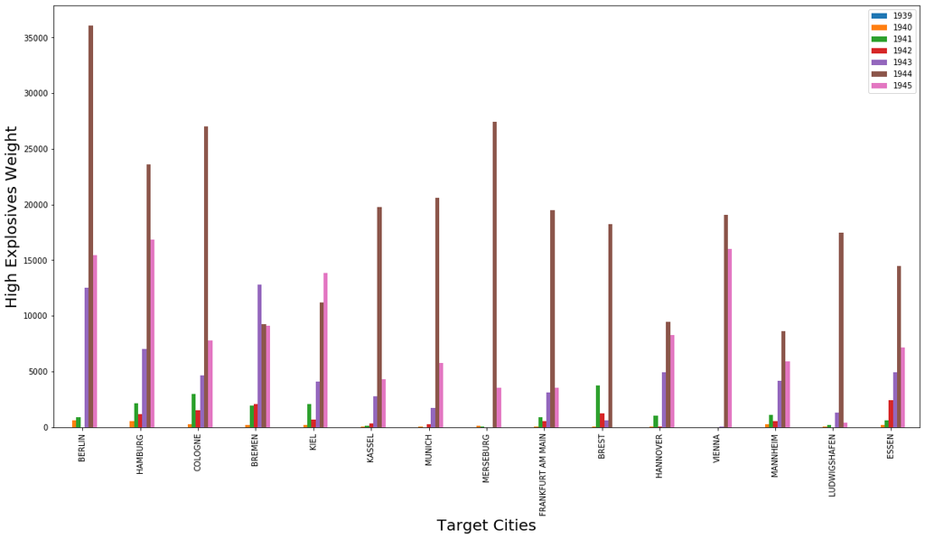

```python
fig,ax=plt.subplots()
ax.set_ylabel('High Explosives Weight',size=20)
ax.set_xlabel('Target Cities',size=20)


df_city_year.plot.bar(ax=ax);
```

**Because the plot above might be misleading (by making it look like 1945 was fairly peaceful) we now plot the daily average of each year**

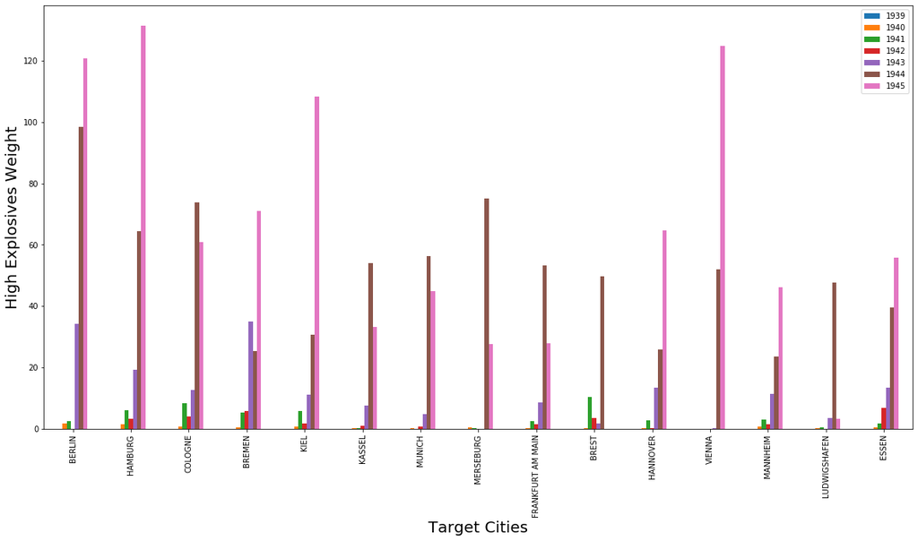

```python
df_city_daily_mean = df_city_year.copy()
df_city_daily_mean[1939] = df_city_year[1939]/(30+31+30+31) # WW2 began on 1st September 1939
df_city_daily_mean[[1941,1942,1943]] = df_city_year[[1941,1942,1943]]/365
df_city_daily_mean[[1940,1944]] = df_city_year[[1940,1944]]/366 # 1940 and 1944 were leap-years
df_city_daily_mean[1945] = df_city_year[1945]/(31+28+31+30+8) # WW2 ended on 8th Mai 1945

fig,ax=plt.subplots()
ax.set_ylabel('High Explosives Weight',size=20)
ax.set_xlabel('Target Cities',size=20)

df_city_daily_mean.plot.bar(ax=ax);
```

**Most frequently attacked cities and their cumulated amount of high explosives**

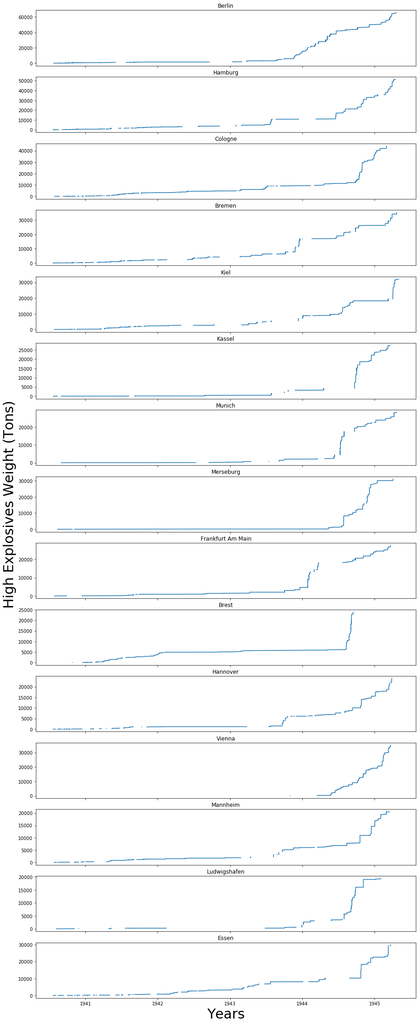

```python
rows, cols = 15, 1
fig, ax = plt.subplots(rows, cols, sharex="col", figsize=(15,40))
ax[-1].set_xlabel("Years",size=30)
ax[rows//2].set_ylabel("High Explosives Weight (Tons)",size=30) # Setze y_label nur in der mittleren Zeile

city_index = 0
for row in range(rows):
    city = cities[city_index]
    ax[row].set_title(city.title())
    x = df_tar.loc[df_tar['Target City'] == city]['Mission Date']
    y = np.cumsum(df_tar.loc[df_tar['Target City'] == city]['High Explosives Weight (Tons)'])
    ax[row].plot(x,y)
    city_index += 1
```

**Visualisation of the most frequently attacked cities and their cumulated amount of high explosives on a map**

```python
#erstellt top15_geo
#top15_geo enthält die Informationen von df_city_year + die Koordinaten der jeweiligen Städte
#und ist ein GeoDataFrame

top_cities = cities[0:15]

coordinates = []

for stadt in top_cities:
    target = df_tar.loc[lambda df_tar_anfang: df_tar_anfang['Target City'] == stadt]
    zahl = len(target['geometry'].unique())
    coordinates.append(target['geometry'].unique()[0])#verwende unique()[0], falls unterschiedliche Koordinaten vorkommen


top15_geo = gpd.GeoDataFrame(df_city_year, geometry=coordinates)
top15_geo
```

|  | 1939 | 1940 | 1941 | 1942 | 1943 | 1944 | 1945 | geometry |
| --- | --- | --- | --- | --- | --- | --- | --- | --- |
| BERLIN | 0.0 | 583.0 | 886.0 | 2.0 | 12498.0 | 36083.0 | 15452.0 | POINT (13.36667 52.51667) |
| HAMBURG | 0.0 | 550.0 | 2159.0 | 1145.0 | 7026.0 | 23630.0 | 16833.0 | POINT (10.00000 53.55000) |
| COLOGNE | 0.0 | 228.0 | 2994.0 | 1480.0 | 4651.0 | 27003.0 | 7803.0 | POINT (6.95000 50.93000) |
| BREMEN | 0.0 | 177.0 | 1913.0 | 2089.0 | 12785.0 | 9241.0 | 9088.0 | POINT (8.72000 53.08000) |
| KIEL | 0.0 | 220.0 | 2101.0 | 645.0 | 4087.0 | 11200.0 | 13863.0 | POINT (10.15000 54.33000) |
| KASSEL | 0.0 | 21.0 | 82.0 | 324.0 | 2771.0 | 19738.0 | 4264.0 | POINT (9.47000 51.32000) |
| MUNICH | 0.0 | 30.0 | 5.0 | 280.0 | 1695.0 | 20575.0 | 5736.0 | POINT (11.58000 48.13000) |
| MERSEBURG | 0.0 | 116.0 | 28.0 | 0.0 | 0.0 | 27464.0 | 3548.0 | POINT (12.00000 51.35000) |
| FRANKFURT AM MAIN | 0.0 | 68.0 | 853.0 | 564.0 | 3134.0 | 19492.0 | 3553.0 | POINT (8.67000 50.10000) |
| BREST | 0.0 | 20.0 | 3760.0 | 1258.0 | 617.0 | 18215.0 | 0.0 | POINT (-4.50000 48.40000) |
| HANNOVER | 0.0 | 74.0 | 1032.0 | 52.0 | 4912.0 | 9447.0 | 8268.0 | POINT (9.73000 52.38000) |
| VIENNA | 0.0 | 0.0 | 0.0 | 0.0 | 27.0 | 19062.0 | 15986.0 | POINT (16.37000 48.20000) |
| MANNHEIM | 0.0 | 235.0 | 1068.0 | 546.0 | 4136.0 | 8585.0 | 5891.0 | POINT (8.47000 49.48000) |
| LUDWIGSHAFEN | 0.0 | 77.0 | 188.0 | 7.0 | 1268.0 | 17448.0 | 410.0 | POINT (8.45000 49.47000) |
| ESSEN | 0.0 | 164.0 | 595.0 | 2441.0 | 4896.0 | 14444.0 | 7131.0 | POINT (7.00000 51.43000) |

```python
#Hilfsfunktion, gibt die Menge des Sprengstoffs einer Stadt in einem Jahr an
def explosives(city, year):
    value = top15_geo.loc[city, year]
    return value
```

```python
#Erstellt array, bei dem das i + 1 -te Element alle Elemente aus top_cities außer das i-te enthält
array = []
for i in range(15):
    array.append(np.append(top_cities[:i], top_cities[i+1:]))
```

```python
#Erstellt Geodataframes geo_index mit nur einer Zeile. Der Index einer Stadt stimmt mit dem in top_cities überein
for k in range(15):
    exec(f'geo_{k} = top15_geo.copy().drop(array[k])')
```

**1940**

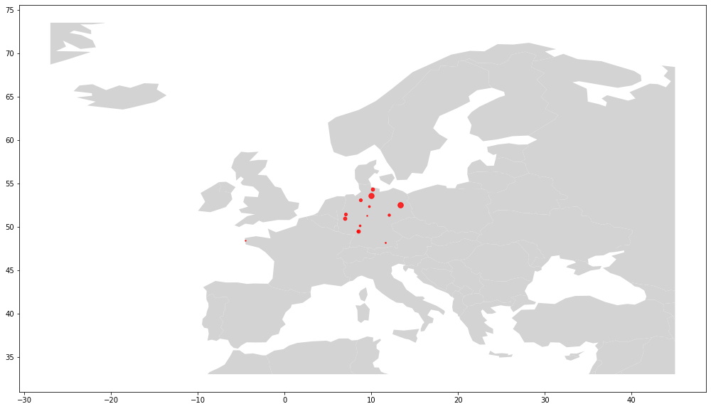

```python
base = europe.plot(facecolor='lightgray')
year = 1940
scale = 10
geo_0.plot(ax=base, marker='o', color='red', markersize=explosives(top_cities[0], year)/scale, alpha=0.8);
geo_1.plot(ax=base, marker='o', color='red', markersize=explosives(top_cities[1], year)/scale, alpha=0.8);
geo_2.plot(ax=base, marker='o', color='red', markersize=explosives(top_cities[2], year)/scale, alpha=0.8);
geo_3.plot(ax=base, marker='o', color='red', markersize=explosives(top_cities[3], year)/scale, alpha=0.8);
geo_4.plot(ax=base, marker='o', color='red', markersize=explosives(top_cities[4], year)/scale, alpha=0.8);
geo_5.plot(ax=base, marker='o', color='red', markersize=explosives(top_cities[5], year)/scale, alpha=0.8);
geo_6.plot(ax=base, marker='o', color='red', markersize=explosives(top_cities[6], year)/scale, alpha=0.8);
geo_7.plot(ax=base, marker='o', color='red', markersize=explosives(top_cities[7], year)/scale, alpha=0.8);
geo_8.plot(ax=base, marker='o', color='red', markersize=explosives(top_cities[8], year)/scale, alpha=0.8);
geo_9.plot(ax=base, marker='o', color='red', markersize=explosives(top_cities[9], year)/scale, alpha=0.8);
geo_10.plot(ax=base, marker='o', color='red', markersize=explosives(top_cities[10], year)/scale, alpha=0.8);
geo_11.plot(ax=base, marker='o', color='red', markersize=explosives(top_cities[11], year)/scale, alpha=0.8);
geo_12.plot(ax=base, marker='o', color='red', markersize=explosives(top_cities[12], year)/scale, alpha=0.8);
geo_13.plot(ax=base, marker='o', color='red', markersize=explosives(top_cities[13], year)/scale, alpha=0.8);
geo_14.plot(ax=base, marker='o', color='red', markersize=explosives(top_cities[14], year)/scale, alpha=0.8);
```

**1941**

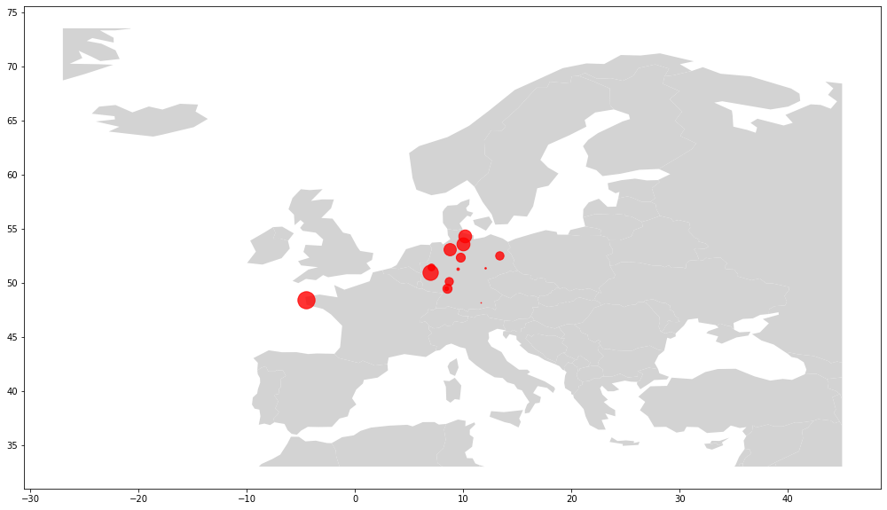

```python
base = europe.plot(facecolor='lightgray')
year = 1941
scale = 10
geo_0.plot(ax=base, marker='o', color='red', markersize=explosives(top_cities[0], year)/scale, alpha=0.8);
geo_1.plot(ax=base, marker='o', color='red', markersize=explosives(top_cities[1], year)/scale, alpha=0.8);
geo_2.plot(ax=base, marker='o', color='red', markersize=explosives(top_cities[2], year)/scale, alpha=0.8);
geo_3.plot(ax=base, marker='o', color='red', markersize=explosives(top_cities[3], year)/scale, alpha=0.8);
geo_4.plot(ax=base, marker='o', color='red', markersize=explosives(top_cities[4], year)/scale, alpha=0.8);
geo_5.plot(ax=base, marker='o', color='red', markersize=explosives(top_cities[5], year)/scale, alpha=0.8);
geo_6.plot(ax=base, marker='o', color='red', markersize=explosives(top_cities[6], year)/scale, alpha=0.8);
geo_7.plot(ax=base, marker='o', color='red', markersize=explosives(top_cities[7], year)/scale, alpha=0.8);
geo_8.plot(ax=base, marker='o', color='red', markersize=explosives(top_cities[8], year)/scale, alpha=0.8);
geo_9.plot(ax=base, marker='o', color='red', markersize=explosives(top_cities[9], year)/scale, alpha=0.8);
geo_10.plot(ax=base, marker='o', color='red', markersize=explosives(top_cities[10], year)/scale, alpha=0.8);
geo_11.plot(ax=base, marker='o', color='red', markersize=explosives(top_cities[11], year)/scale, alpha=0.8);
geo_12.plot(ax=base, marker='o', color='red', markersize=explosives(top_cities[12], year)/scale, alpha=0.8);
geo_13.plot(ax=base, marker='o', color='red', markersize=explosives(top_cities[13], year)/scale, alpha=0.8);
geo_14.plot(ax=base, marker='o', color='red', markersize=explosives(top_cities[14], year)/scale, alpha=0.8);
```

**1942**

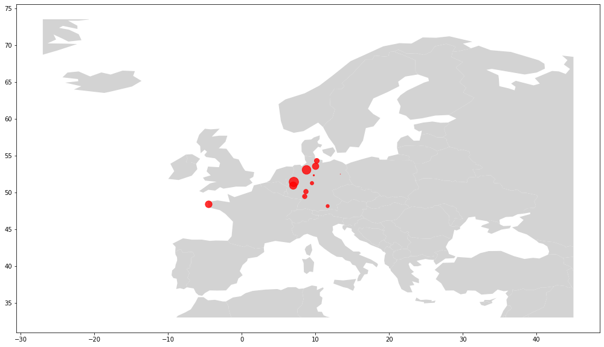

```python
base = europe.plot(facecolor='lightgray')
year = 1942
scale = 10
geo_0.plot(ax=base, marker='o', color='red', markersize=explosives(top_cities[0], year)/scale, alpha=0.8);
geo_1.plot(ax=base, marker='o', color='red', markersize=explosives(top_cities[1], year)/scale, alpha=0.8);
geo_2.plot(ax=base, marker='o', color='red', markersize=explosives(top_cities[2], year)/scale, alpha=0.8);
geo_3.plot(ax=base, marker='o', color='red', markersize=explosives(top_cities[3], year)/scale, alpha=0.8);
geo_4.plot(ax=base, marker='o', color='red', markersize=explosives(top_cities[4], year)/scale, alpha=0.8);
geo_5.plot(ax=base, marker='o', color='red', markersize=explosives(top_cities[5], year)/scale, alpha=0.8);
geo_6.plot(ax=base, marker='o', color='red', markersize=explosives(top_cities[6], year)/scale, alpha=0.8);
geo_7.plot(ax=base, marker='o', color='red', markersize=explosives(top_cities[7], year)/scale, alpha=0.8);
geo_8.plot(ax=base, marker='o', color='red', markersize=explosives(top_cities[8], year)/scale, alpha=0.8);
geo_9.plot(ax=base, marker='o', color='red', markersize=explosives(top_cities[9], year)/scale, alpha=0.8);
geo_10.plot(ax=base, marker='o', color='red', markersize=explosives(top_cities[10], year)/scale, alpha=0.8);
geo_11.plot(ax=base, marker='o', color='red', markersize=explosives(top_cities[11], year)/scale, alpha=0.8);
geo_12.plot(ax=base, marker='o', color='red', markersize=explosives(top_cities[12], year)/scale, alpha=0.8);
geo_13.plot(ax=base, marker='o', color='red', markersize=explosives(top_cities[13], year)/scale, alpha=0.8);
geo_14.plot(ax=base, marker='o', color='red', markersize=explosives(top_cities[14], year)/scale, alpha=0.8);
```

**1943**

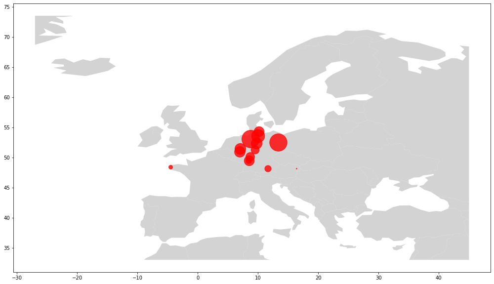

```python
base = europe.plot(facecolor='lightgray')
year = 1943
scale = 10
geo_0.plot(ax=base, marker='o', color='red', markersize=explosives(top_cities[0], year)/scale, alpha=0.8);
geo_1.plot(ax=base, marker='o', color='red', markersize=explosives(top_cities[1], year)/scale, alpha=0.8);
geo_2.plot(ax=base, marker='o', color='red', markersize=explosives(top_cities[2], year)/scale, alpha=0.8);
geo_3.plot(ax=base, marker='o', color='red', markersize=explosives(top_cities[3], year)/scale, alpha=0.8);
geo_4.plot(ax=base, marker='o', color='red', markersize=explosives(top_cities[4], year)/scale, alpha=0.8);
geo_5.plot(ax=base, marker='o', color='red', markersize=explosives(top_cities[5], year)/scale, alpha=0.8);
geo_6.plot(ax=base, marker='o', color='red', markersize=explosives(top_cities[6], year)/scale, alpha=0.8);
geo_7.plot(ax=base, marker='o', color='red', markersize=explosives(top_cities[7], year)/scale, alpha=0.8);
geo_8.plot(ax=base, marker='o', color='red', markersize=explosives(top_cities[8], year)/scale, alpha=0.8);
geo_9.plot(ax=base, marker='o', color='red', markersize=explosives(top_cities[9], year)/scale, alpha=0.8);
geo_10.plot(ax=base, marker='o', color='red', markersize=explosives(top_cities[10], year)/scale, alpha=0.8);
geo_11.plot(ax=base, marker='o', color='red', markersize=explosives(top_cities[11], year)/scale, alpha=0.8);
geo_12.plot(ax=base, marker='o', color='red', markersize=explosives(top_cities[12], year)/scale, alpha=0.8);
geo_13.plot(ax=base, marker='o', color='red', markersize=explosives(top_cities[13], year)/scale, alpha=0.8);
geo_14.plot(ax=base, marker='o', color='red', markersize=explosives(top_cities[14], year)/scale, alpha=0.8);
```

**1944**

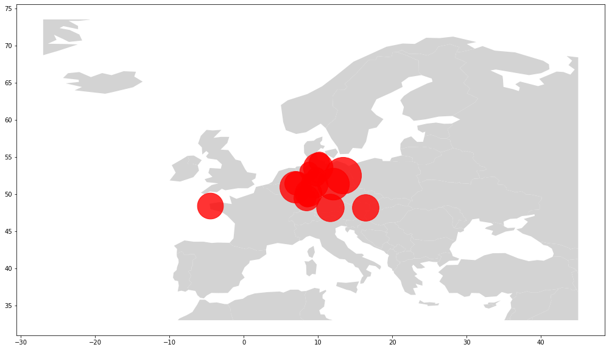

```python
base = europe.plot(facecolor='lightgray')
year = 1944
scale = 10
geo_0.plot(ax=base, marker='o', color='red', markersize=explosives(top_cities[0], year)/scale, alpha=0.8);
geo_1.plot(ax=base, marker='o', color='red', markersize=explosives(top_cities[1], year)/scale, alpha=0.8);
geo_2.plot(ax=base, marker='o', color='red', markersize=explosives(top_cities[2], year)/scale, alpha=0.8);
geo_3.plot(ax=base, marker='o', color='red', markersize=explosives(top_cities[3], year)/scale, alpha=0.8);
geo_4.plot(ax=base, marker='o', color='red', markersize=explosives(top_cities[4], year)/scale, alpha=0.8);
geo_5.plot(ax=base, marker='o', color='red', markersize=explosives(top_cities[5], year)/scale, alpha=0.8);
geo_6.plot(ax=base, marker='o', color='red', markersize=explosives(top_cities[6], year)/scale, alpha=0.8);
geo_7.plot(ax=base, marker='o', color='red', markersize=explosives(top_cities[7], year)/scale, alpha=0.8);
geo_8.plot(ax=base, marker='o', color='red', markersize=explosives(top_cities[8], year)/scale, alpha=0.8);
geo_9.plot(ax=base, marker='o', color='red', markersize=explosives(top_cities[9], year)/scale, alpha=0.8);
geo_10.plot(ax=base, marker='o', color='red', markersize=explosives(top_cities[10], year)/scale, alpha=0.8);
geo_11.plot(ax=base, marker='o', color='red', markersize=explosives(top_cities[11], year)/scale, alpha=0.8);
geo_12.plot(ax=base, marker='o', color='red', markersize=explosives(top_cities[12], year)/scale, alpha=0.8);
geo_13.plot(ax=base, marker='o', color='red', markersize=explosives(top_cities[13], year)/scale, alpha=0.8);
geo_14.plot(ax=base, marker='o', color='red', markersize=explosives(top_cities[14], year)/scale, alpha=0.8);
```

**1945**

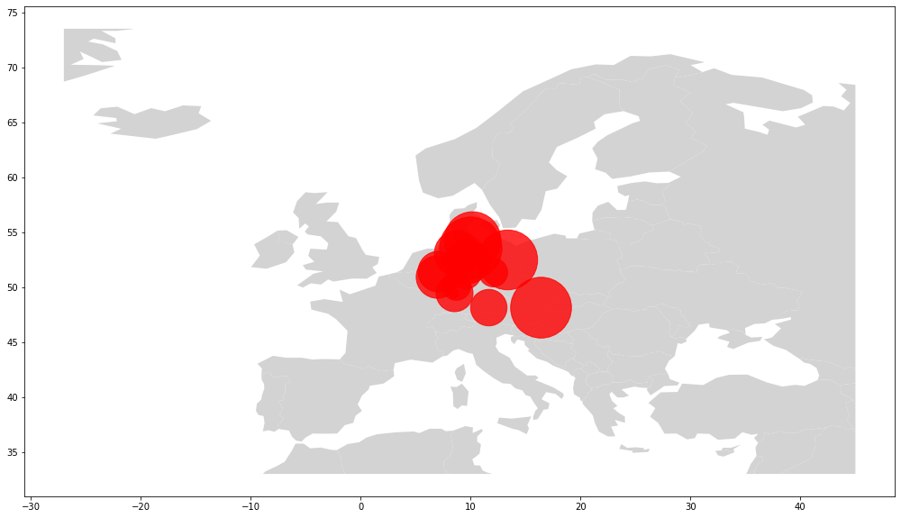

```python
base = europe.plot(facecolor='lightgray')
year = 1945
scale = (31+28+31+30+8)/36.5 # 365/365 would've been 10, because WW2 fortunately didn't last
                             # for the whole year of 1945, we need to modify the scale
geo_0.plot(ax=base, marker='o', color='red', markersize=explosives(top_cities[0], year)/scale, alpha=0.8);
geo_1.plot(ax=base, marker='o', color='red', markersize=explosives(top_cities[1], year)/scale, alpha=0.8);
geo_2.plot(ax=base, marker='o', color='red', markersize=explosives(top_cities[2], year)/scale, alpha=0.8);
geo_3.plot(ax=base, marker='o', color='red', markersize=explosives(top_cities[3], year)/scale, alpha=0.8);
geo_4.plot(ax=base, marker='o', color='red', markersize=explosives(top_cities[4], year)/scale, alpha=0.8);
geo_5.plot(ax=base, marker='o', color='red', markersize=explosives(top_cities[5], year)/scale, alpha=0.8);
geo_6.plot(ax=base, marker='o', color='red', markersize=explosives(top_cities[6], year)/scale, alpha=0.8);
geo_7.plot(ax=base, marker='o', color='red', markersize=explosives(top_cities[7], year)/scale, alpha=0.8);
geo_8.plot(ax=base, marker='o', color='red', markersize=explosives(top_cities[8], year)/scale, alpha=0.8);
geo_9.plot(ax=base, marker='o', color='red', markersize=explosives(top_cities[9], year)/scale, alpha=0.8);
geo_10.plot(ax=base, marker='o', color='red', markersize=explosives(top_cities[10], year)/scale, alpha=0.8);
geo_11.plot(ax=base, marker='o', color='red', markersize=explosives(top_cities[11], year)/scale, alpha=0.8);
geo_12.plot(ax=base, marker='o', color='red', markersize=explosives(top_cities[12], year)/scale, alpha=0.8);
geo_13.plot(ax=base, marker='o', color='red', markersize=explosives(top_cities[13], year)/scale, alpha=0.8);
geo_14.plot(ax=base, marker='o', color='red', markersize=explosives(top_cities[14], year)/scale, alpha=0.8);
```